# Zillow Home Index Analysis: NC, SC, FL

## Klingler, Matt

### June 2023

```r
#Loading libraries
library(tidyverse)
library(skimr)
#Load data
sfSales <- read_csv("SingleFamilyResidenceSales.csv")
options(scipen=999)
```

This data comes from Zillow and was used to explore home values in possible living locations for my family throughout North Carolina, South Carolina, and Florida. In the early 2010’s after a few vacations to South Carolina, we decided to make our home along the coast. We love the small coastal town atmosphere!

### Set and Clean for NC, SC, FL

```r
#Select only NC, SC, FL
sfhomest <- filter(sfSales, State %in% c("NC", "SC", "FL"))

#Select specified columns
sfhomest <- select(sfhomest, RegionName, State, CountyName, Metro, "2005-05","2006-05","2007-05","2008-05","2009-05","2010-05","2011-05","2012-05","2013-05","2014-05","2015-05","2016-05","2017-05","2018-05")

#Rename Columns
sfhomest <- rename(sfhomest,"2005"="2005-05","2006"="2006-05","2007"="2007-05","2008"="2008-05","2009"="2009-05","2010"="2010-05","2011"="2011-05","2012"="2012-05","2013"="2013-05","2014"="2014-05","2015"="2015-05","2016"="2016-05","2017"="2017-05","2018"="2018-05" )

#Clean/Tidy to make easier for analysis
sfhomest <- sfhomest %>%
  pivot_longer(c("2005","2006","2007","2008","2009","2010","2011","2012","2013","2014","2015","2016","2017","2018"), names_to="YR",values_to="ZHVI")
```

Here we will further filter down the results for the regions desired and setting the home value threshold at $375,000. Which for us is still way out of our range, but this is for exploratory purposes after all!

```r
ncsf <- filter(sfhomest, State == "NC" & ZHVI <= 375000)
ncsf <- filter(ncsf, CountyName %in% c("Craven County", "Onslow County", "Carteret County", "Pender County", "New Hanover County","Brunswick County", "Pamlico County", "Hyde County"))

scsf <- filter(sfhomest, State == "SC" & ZHVI <= 375000)
scsf <- filter(scsf, CountyName %in% c("Horry County", "Georgetown County", "Charleston County", "Beaufort County", "Jasper County", "Colleton County"))


flsf <- filter(sfhomest, State == "FL" & ZHVI <= 375000)
flsfnorth <- filter(flsf, CountyName %in% c("Nassau County", "Duval County", "Saint Johns County", "Clay County", "Putnam County", "Levy County", "Marion County", "Alachua County", "Citrus County", "Sumter County"))

flsfsouth <- filter(flsf, CountyName %in% c("Collier County", "Lee County", "Charlotte County", "De Soto County", "Hardee County", "Manatee County", "Sarasota County", "Hernando County", "Pasco County", "Polk County"))
```

Great! so now we have selected and cleaned the data for NC, SC, and FL for easier analysis. Now to begin exploring!

### Explore the Data

```r
#Statistical Summary
summary(ncsf$ZHVI)
```

```
##    Min. 1st Qu.  Median    Mean 3rd Qu.    Max.
##   65100  134500  167100  180208  208400  371900
```

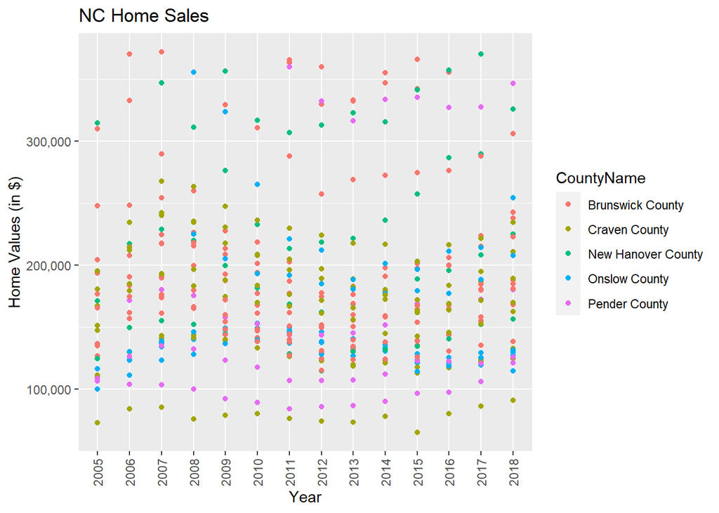

```r
#Scatter Plot
ggplot(ncsf, aes(x=YR, y=ZHVI, color=CountyName)) +
  geom_point() +
  theme(axis.text.x = element_text(angle = 90, vjust=0.5)) +
  scale_y_continuous(name="Home Values (in $)", labels = scales::comma) +
  labs(title = "NC Home Sales",
       x="Year")
```

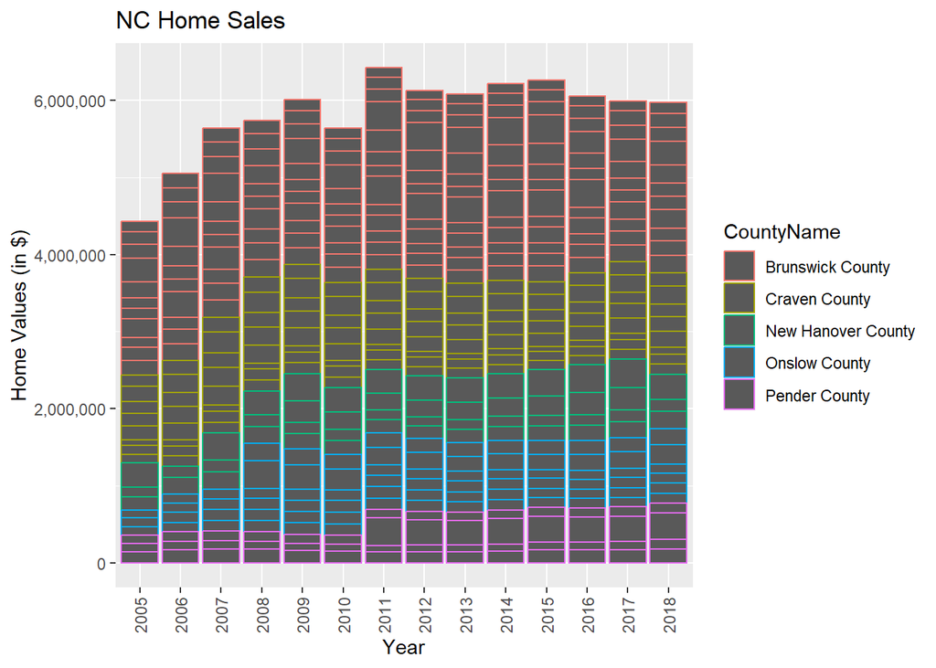

```r
#Stacked Column Chart
ggplot(ncsf, aes(x=YR, y=ZHVI, color=CountyName)) +
  geom_col() +
  theme(axis.text.x = element_text(angle = 90, vjust=0.5)) +
  scale_y_continuous(name="Home Values (in $)", labels = scales::comma) +
  labs(title = "NC Home Sales",
       x="Year")
```

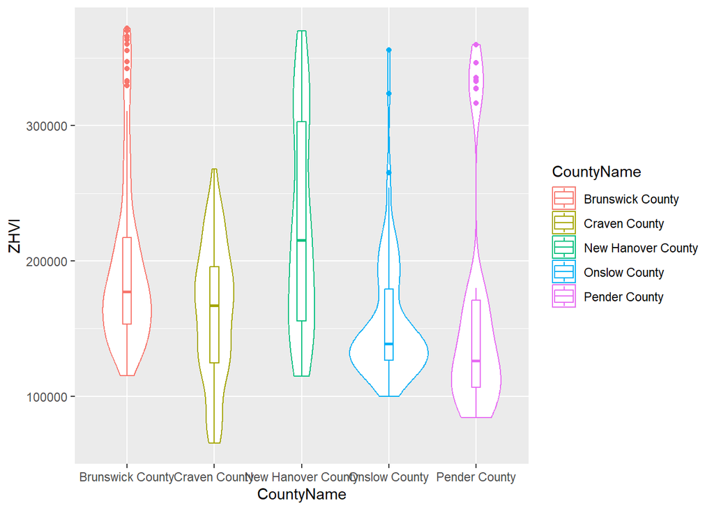

```r
#Box and Violin Plot
ggplot(ncsf, aes(x=CountyName, y=ZHVI, color = CountyName)) +
  geom_violin() +
  geom_boxplot(width=0.1)
```

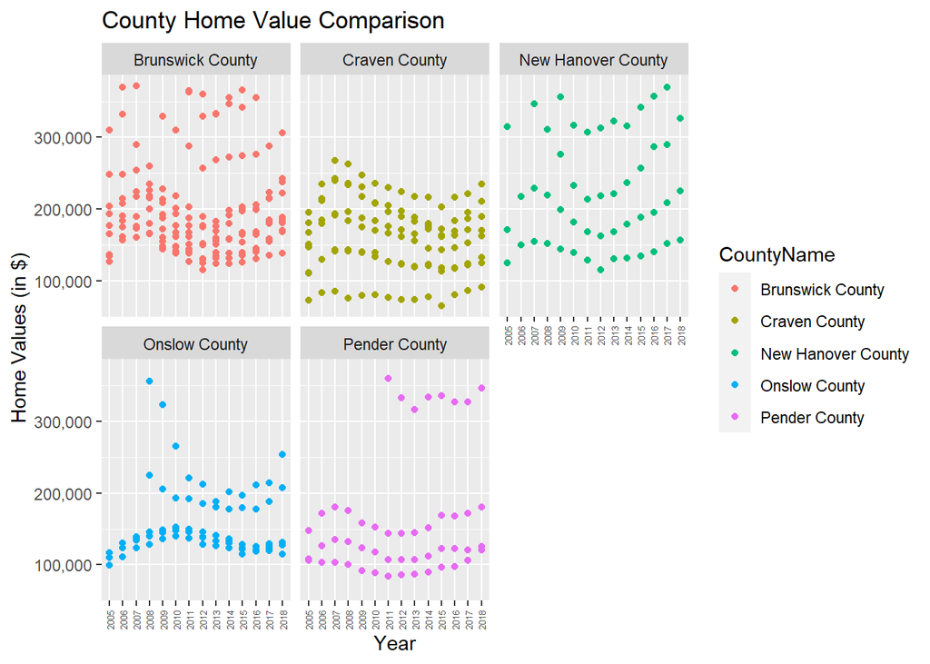

```r
#Scatter Multiple Plot
ggplot(ncsf, aes(x=YR, y=ZHVI, color = CountyName)) +
  geom_point() +
  facet_wrap(~CountyName) +
  theme(axis.text.x = element_text(angle = 90, vjust=0.5, size=5)) +
  scale_y_continuous(name="Home Values (in $)", labels = scales::comma) +
  labs(title = "County Home Value Comparison",
       x="Year")
```

```r
#Statistical Summary
summary(scsf$ZHVI)
```

```
##    Min. 1st Qu.  Median    Mean 3rd Qu.    Max.
##   56600  134400  173350  190665  242975  370500
```

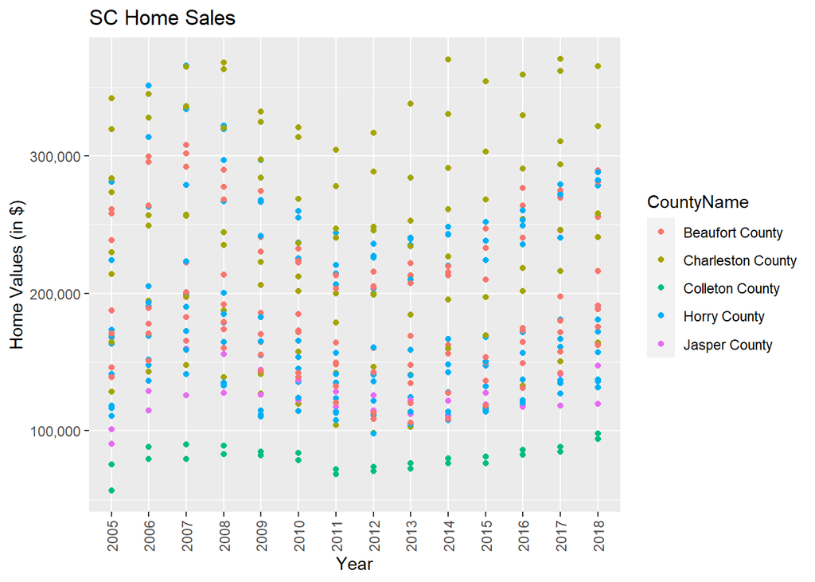

```r
#Scatter Plot
ggplot(scsf, aes(x=YR, y=ZHVI, color=CountyName)) +
  geom_point() +
  theme(axis.text.x = element_text(angle = 90, vjust=0.5)) +
  scale_y_continuous(name="Home Values (in $)", labels = scales::comma) +
  labs(title = "SC Home Sales",
       x="Year")
```

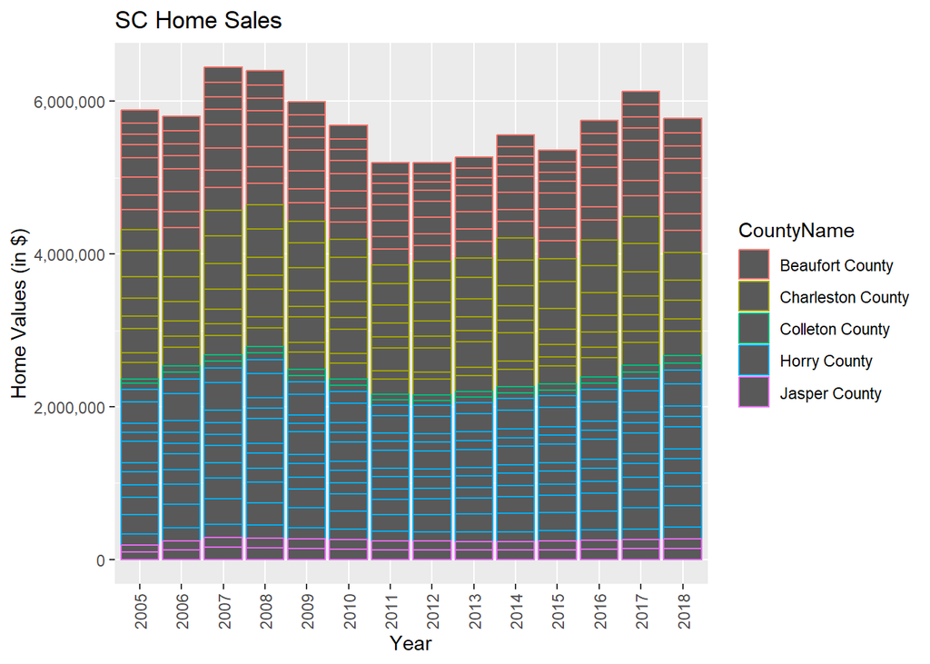

```r
#Stacked Column Chart
ggplot(scsf, aes(x=YR, y=ZHVI, color=CountyName)) +
  geom_col() +
  theme(axis.text.x = element_text(angle = 90, vjust=0.5)) +
  scale_y_continuous(name="Home Values (in $)", labels = scales::comma) +
  labs(title = "SC Home Sales",
       x="Year")
```

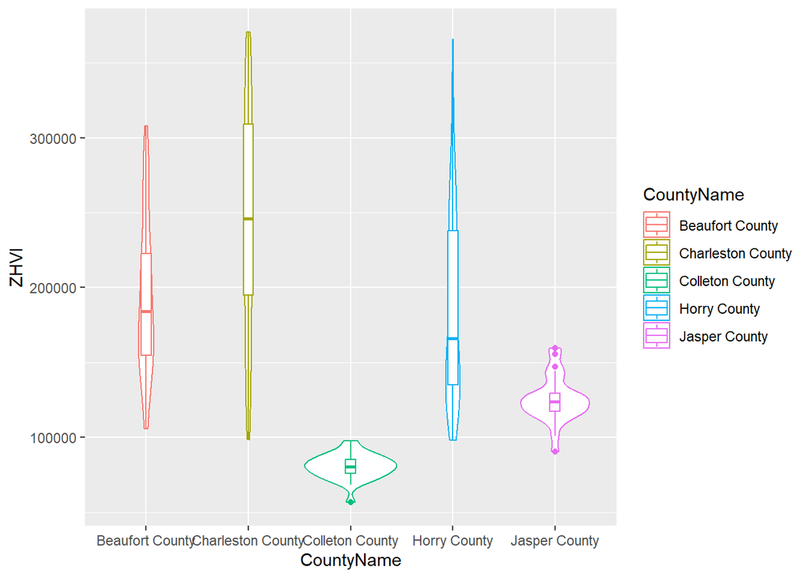

```r
#Box and Violin Plot
ggplot(scsf, aes(x=CountyName, y=ZHVI, color = CountyName)) +
  geom_violin() +
  geom_boxplot(width=0.1)
```

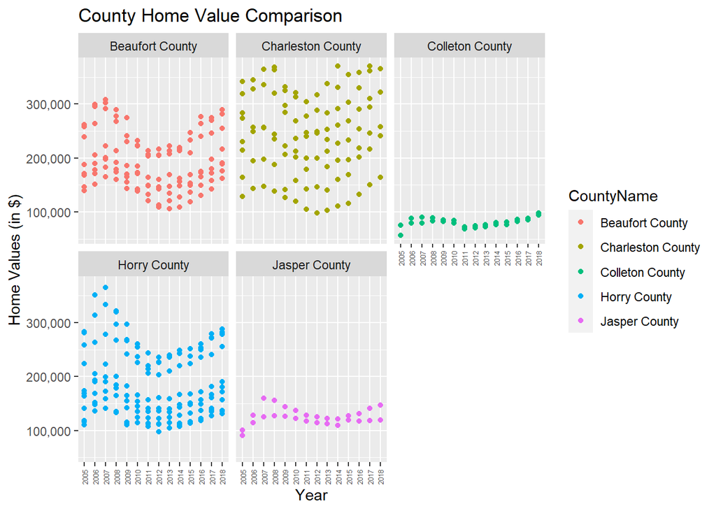

```r
#Scatter Multiple Plot
ggplot(scsf, aes(x=YR, y=ZHVI, color = CountyName)) +
  geom_point() +
  facet_wrap(~CountyName) +
  theme(axis.text.x = element_text(angle = 90, vjust=0.5, size=5)) +
  scale_y_continuous(name="Home Values (in $)", labels = scales::comma) +
  labs(title = "County Home Value Comparison",
       x="Year")
```

```r
#Statistical Summary
summary(flsfnorth$ZHVI)
```

```
##    Min. 1st Qu.  Median    Mean 3rd Qu.    Max.
##   36700  104350  147800  161587  200275  374600
```

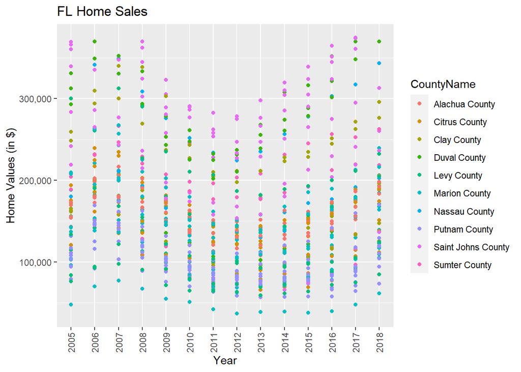

```r
#Scatter Plot
ggplot(flsfnorth, aes(x=YR, y=ZHVI, color=CountyName)) +
  geom_point() +
  theme(axis.text.x = element_text(angle = 90, vjust=0.5)) +
  scale_y_continuous(name="Home Values (in $)", labels = scales::comma) +
  labs(title = "FL Home Sales",
       x="Year")
```

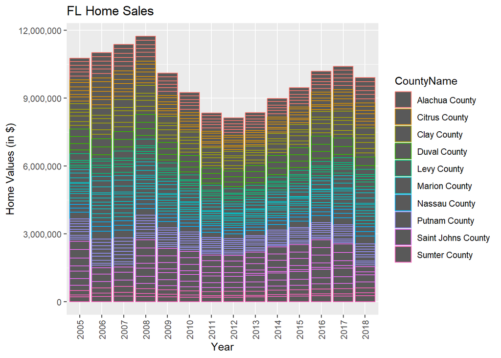

```r
#Stacked Column Chart
ggplot(flsfnorth, aes(x=YR, y=ZHVI, color=CountyName)) +
  geom_col() +
  theme(axis.text.x = element_text(angle = 90, vjust=0.5)) +
  scale_y_continuous(name="Home Values (in $)", labels = scales::comma) +
  labs(title = "FL Home Sales",
       x="Year")
```

```r
#Statistical Summary
summary(flsfsouth$ZHVI)
```

```
##    Min. 1st Qu.  Median    Mean 3rd Qu.    Max.
##   36000  103400  148750  163008  210600  371400
```

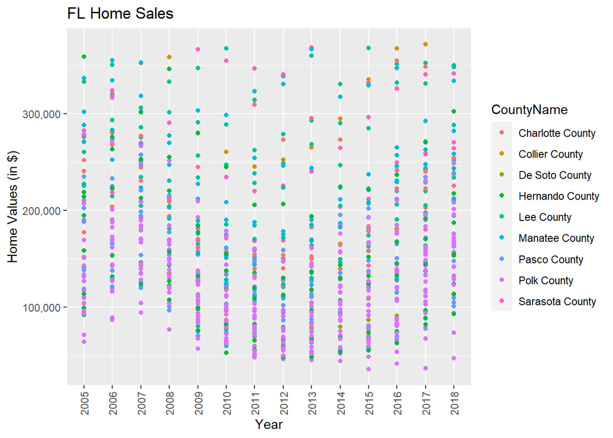

```r
#Scatter Plot
ggplot(flsfsouth, aes(x=YR, y=ZHVI, color=CountyName)) +
  geom_point() +
  theme(axis.text.x = element_text(angle = 90, vjust=0.5)) +
  scale_y_continuous(name="Home Values (in $)", labels = scales::comma) +
  labs(title = "FL Home Sales",
       x="Year")
```

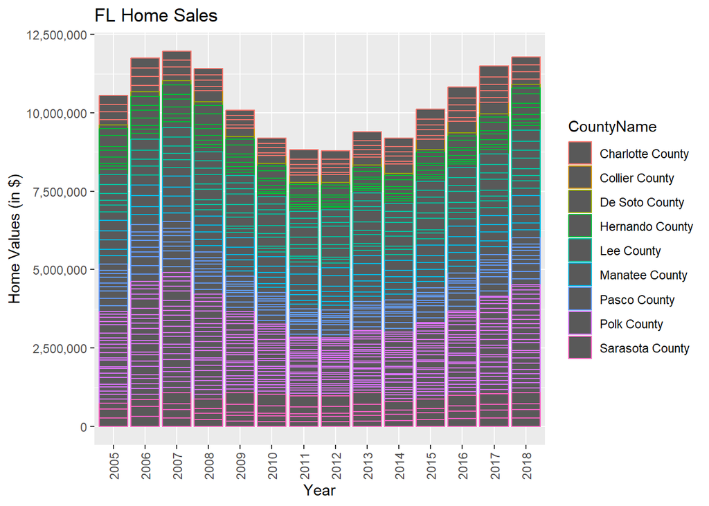

```r
#Stacked Column Chart
ggplot(flsfsouth, aes(x=YR, y=ZHVI, color=CountyName)) +
  geom_col() +
  theme(axis.text.x = element_text(angle = 90, vjust=0.5)) +
  scale_y_continuous(name="Home Values (in $)", labels = scales::comma) +
  labs(title = "FL Home Sales",
       x="Year")
```

Ok, so there are quite a bit of possibilities in FL. NC and SC have a much smaller population density, so there are just over a handful of coastal counties in each. However, FL has many “coastal” counties that we would consider moving to, which complicates the analysis. As you can see, I even broke Florida into a north and south, but this still leaves too much to look at. So now let’s group them into more distinct regions.

```r
flsfjax <- filter(flsf, CountyName %in% c("Nassau County", "Duval County", "Saint Johns County", "Clay County", "Alachua County"))

flsfocala <- filter(flsf, CountyName %in% c("Putnam County", "Levy County", "Marion County", "Citrus County", "Sumter County"))

flsfdadecity <- filter(flsf, CountyName %in% c("Hernando County", "Pasco County", "Polk County", "Hardee County"))

flsfftmyer <- filter(flsf, CountyName %in% c("Manatee County", "Sarasota County", "Charlotte County", "Lee County", "Collier County"))
```

```r
#Statistical Summary
summary(flsfjax$ZHVI)
```

```
##    Min. 1st Qu.  Median    Mean 3rd Qu.    Max.
##   65500  153200  192150  210151  265400  374600
```

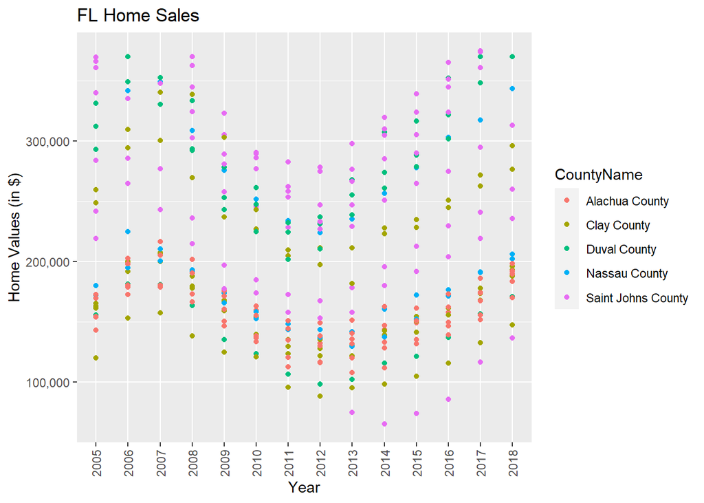

```r
#Scatter Plot
ggplot(flsfjax, aes(x=YR, y=ZHVI, color=CountyName)) +
  geom_point() +
  theme(axis.text.x = element_text(angle = 90, vjust=0.5)) +
  scale_y_continuous(name="Home Values (in $)", labels = scales::comma) +
  labs(title = "FL Home Sales",
       x="Year")
```

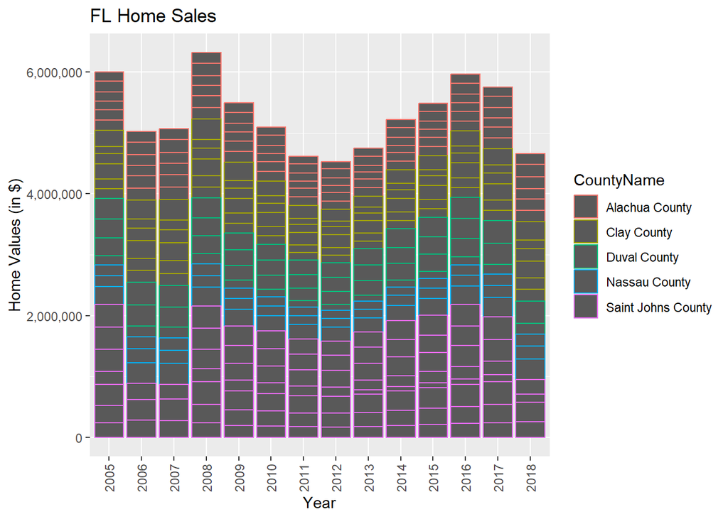

```r
#Stacked Column Chart
ggplot(flsfjax, aes(x=YR, y=ZHVI, color=CountyName)) +
  geom_col() +
  theme(axis.text.x = element_text(angle = 90, vjust=0.5)) +
  scale_y_continuous(name="Home Values (in $)", labels = scales::comma) +
  labs(title = "FL Home Sales",
       x="Year")
```

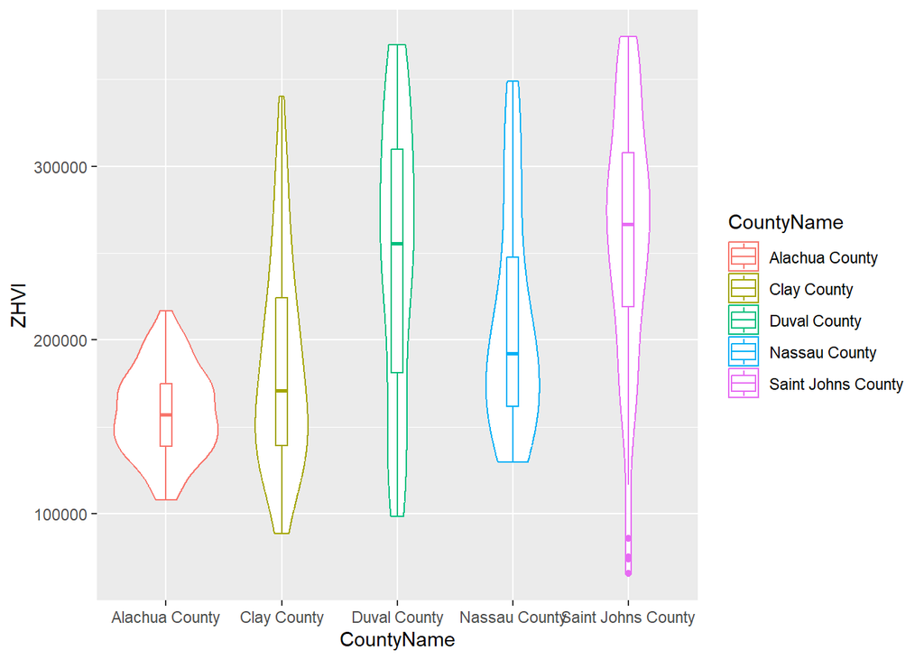

```r
#Box and Violin Plot
ggplot(flsfjax, aes(x=CountyName, y=ZHVI, color = CountyName)) +
  geom_violin() +
  geom_boxplot(width=0.1)
```

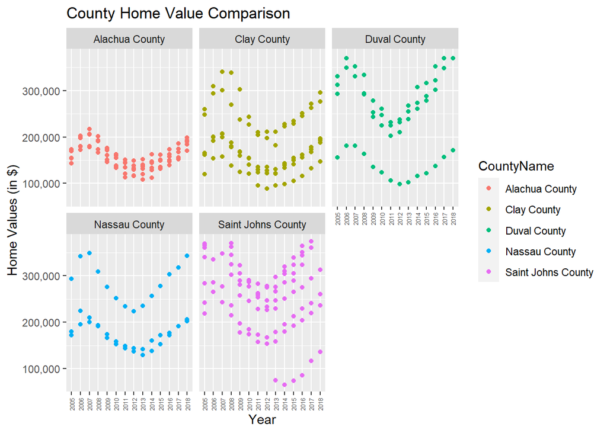

```r
#Scatter Multiple Plot
ggplot(flsfjax, aes(x=YR, y=ZHVI, color = CountyName)) +
  geom_point() +
  facet_wrap(~CountyName) +
  theme(axis.text.x = element_text(angle = 90, vjust=0.5, size=5)) +
  scale_y_continuous(name="Home Values (in $)", labels = scales::comma) +
  labs(title = "County Home Value Comparison",
       x="Year")
```

```r
#Statistical Summary
summary(flsfocala$ZHVI)
```

```
##    Min. 1st Qu.  Median    Mean 3rd Qu.    Max.
##   36700   87550  117400  127534  158275  312700
```

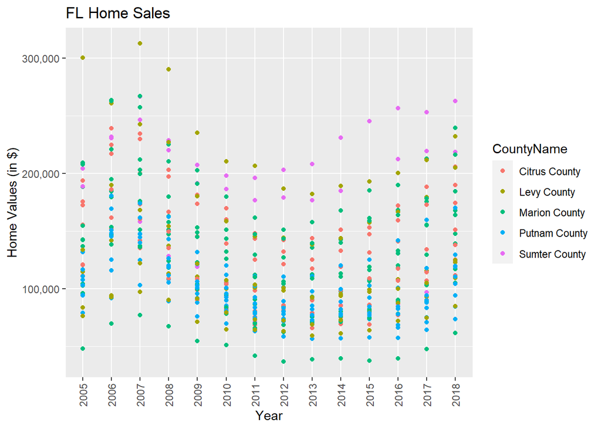

```r
#Scatter Plot
ggplot(flsfocala, aes(x=YR, y=ZHVI, color=CountyName)) +
  geom_point() +
  theme(axis.text.x = element_text(angle = 90, vjust=0.5)) +
  scale_y_continuous(name="Home Values (in $)", labels = scales::comma) +
  labs(title = "FL Home Sales",
       x="Year")
```

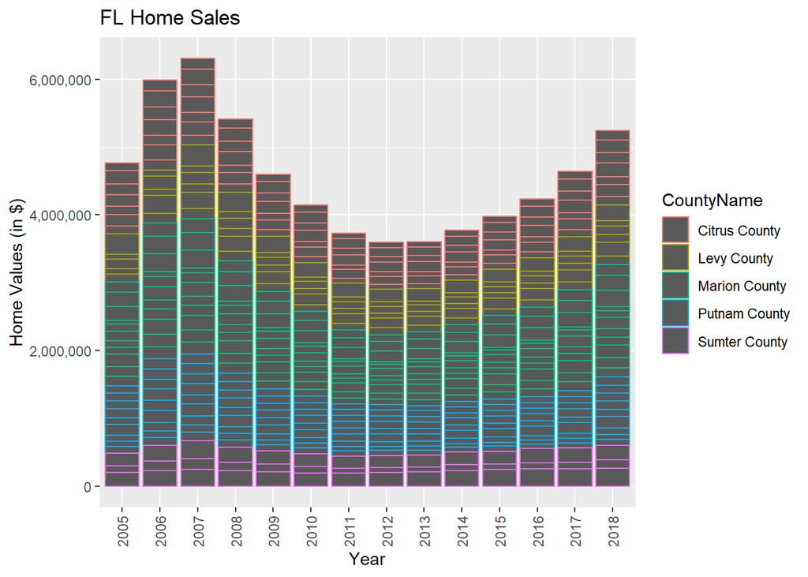

```r
#Stacked Column Chart
ggplot(flsfocala, aes(x=YR, y=ZHVI, color=CountyName)) +
  geom_col() +
  theme(axis.text.x = element_text(angle = 90, vjust=0.5)) +
  scale_y_continuous(name="Home Values (in $)", labels = scales::comma) +
  labs(title = "FL Home Sales",
       x="Year")
```

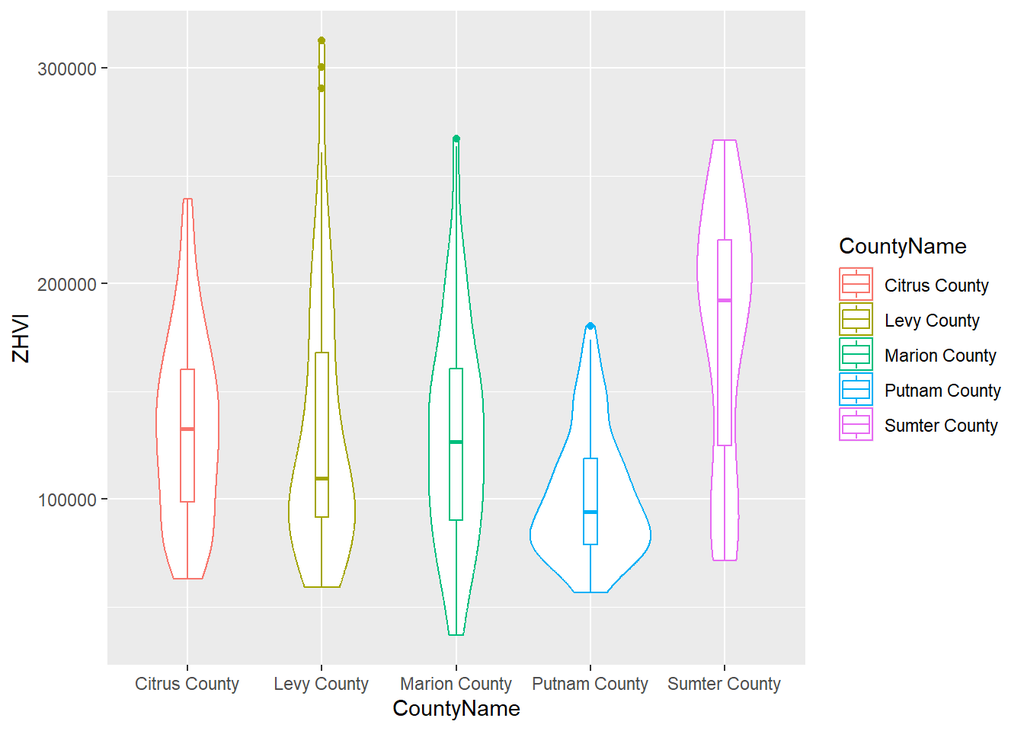

```r
#Box and Violin Plot
ggplot(flsfocala, aes(x=CountyName, y=ZHVI, color = CountyName)) +
  geom_violin() +
  geom_boxplot(width=0.1)
```

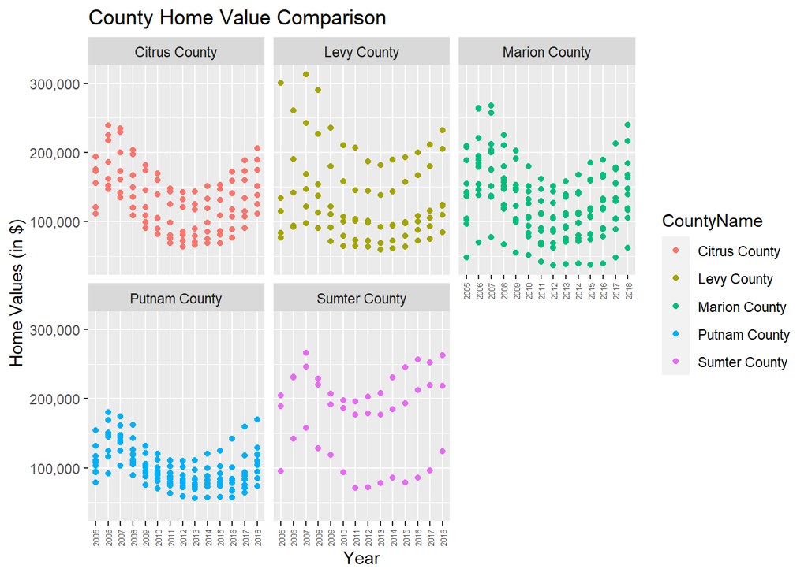

```r
#Scatter Multiple Plot
ggplot(flsfocala, aes(x=YR, y=ZHVI, color = CountyName)) +
  geom_point() +
  facet_wrap(~CountyName) +
  theme(axis.text.x = element_text(angle = 90, vjust=0.5, size=5)) +
  scale_y_continuous(name="Home Values (in $)", labels = scales::comma) +
  labs(title = "County Home Value Comparison",
       x="Year")
```

```r
#Statistical Summary
summary(flsfdadecity$ZHVI)
```

```
##    Min. 1st Qu.  Median    Mean 3rd Qu.    Max.
##   36000   87500  123200  129924  161625  358700
```

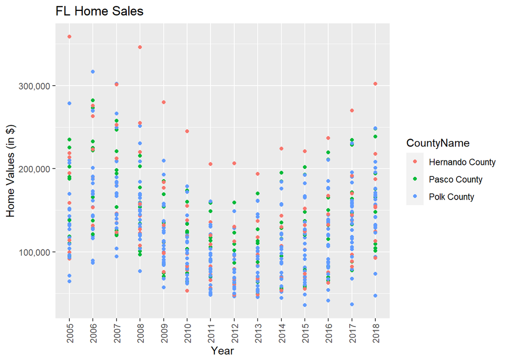

```r
#Scatter Plot
ggplot(flsfdadecity, aes(x=YR, y=ZHVI, color=CountyName)) +
  geom_point() +
  theme(axis.text.x = element_text(angle = 90, vjust=0.5)) +
  scale_y_continuous(name="Home Values (in $)", labels = scales::comma) +
  labs(title = "FL Home Sales",
       x="Year")
```

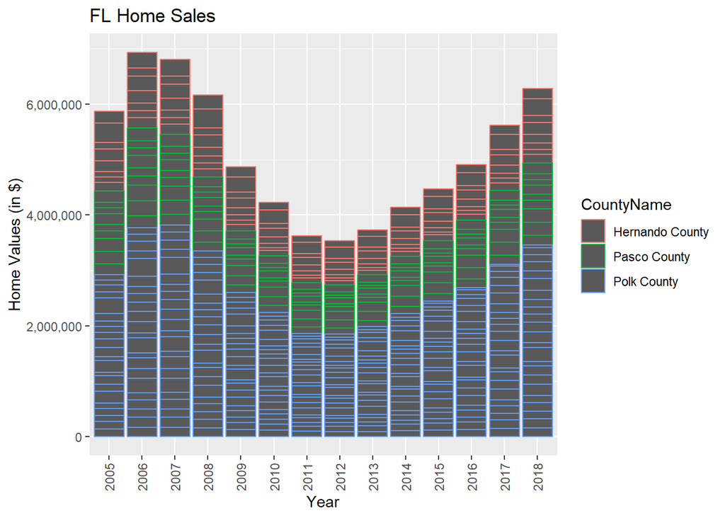

```r
#Stacked Column Chart
ggplot(flsfdadecity, aes(x=YR, y=ZHVI, color=CountyName)) +
  geom_col() +
  theme(axis.text.x = element_text(angle = 90, vjust=0.5)) +
  scale_y_continuous(name="Home Values (in $)", labels = scales::comma) +
  labs(title = "FL Home Sales",
       x="Year")
```

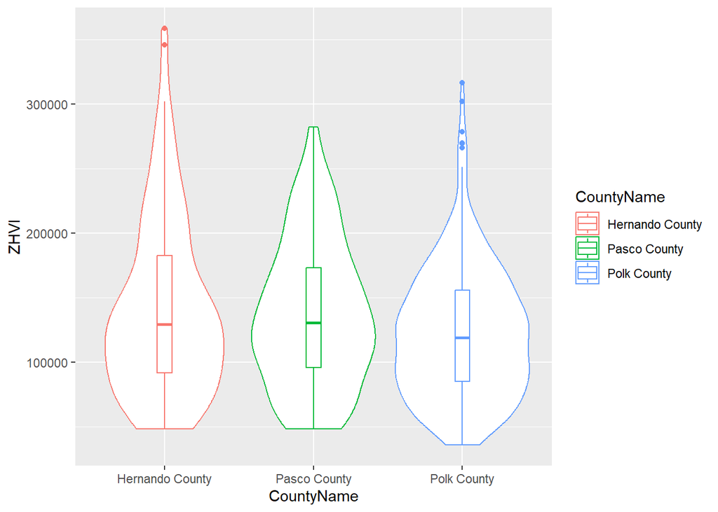

```r
#Box and Violin Plot
ggplot(flsfdadecity, aes(x=CountyName, y=ZHVI, color = CountyName)) +
  geom_violin() +
  geom_boxplot(width=0.1)
```

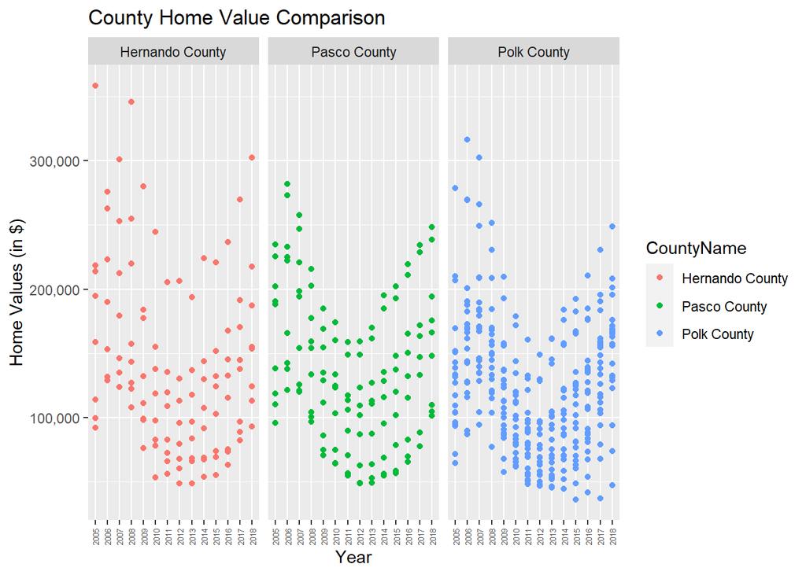

```r
#Scatter Multiple Plot
ggplot(flsfdadecity, aes(x=YR, y=ZHVI, color = CountyName)) +
  geom_point() +
  facet_wrap(~CountyName) +
  theme(axis.text.x = element_text(angle = 90, vjust=0.5, size=5)) +
  scale_y_continuous(name="Home Values (in $)", labels = scales::comma) +
  labs(title = "County Home Value Comparison",
       x="Year")
```

```r
#Statistical Summary
summary(flsfftmyer$ZHVI)
```

```
##    Min. 1st Qu.  Median    Mean 3rd Qu.    Max.
##   59600  163675  219000  220673  273050  371400
```

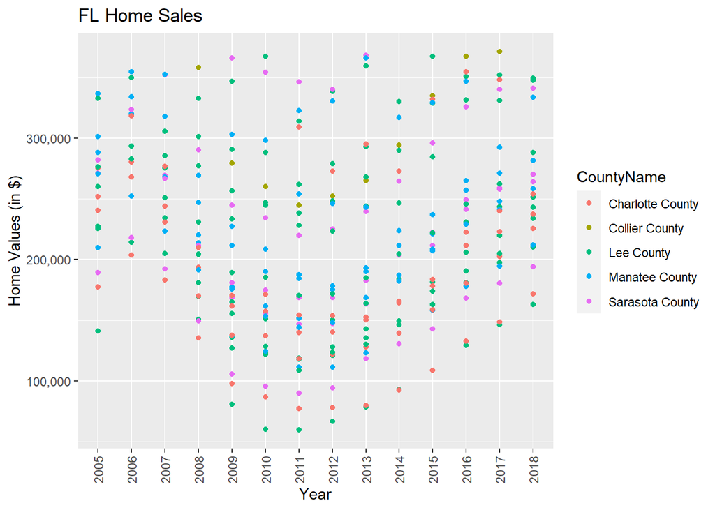

```r
#Scatter Plot
ggplot(flsfftmyer, aes(x=YR, y=ZHVI, color=CountyName)) +
  geom_point() +
  theme(axis.text.x = element_text(angle = 90, vjust=0.5)) +
  scale_y_continuous(name="Home Values (in $)", labels = scales::comma) +
  labs(title = "FL Home Sales",
       x="Year")
```

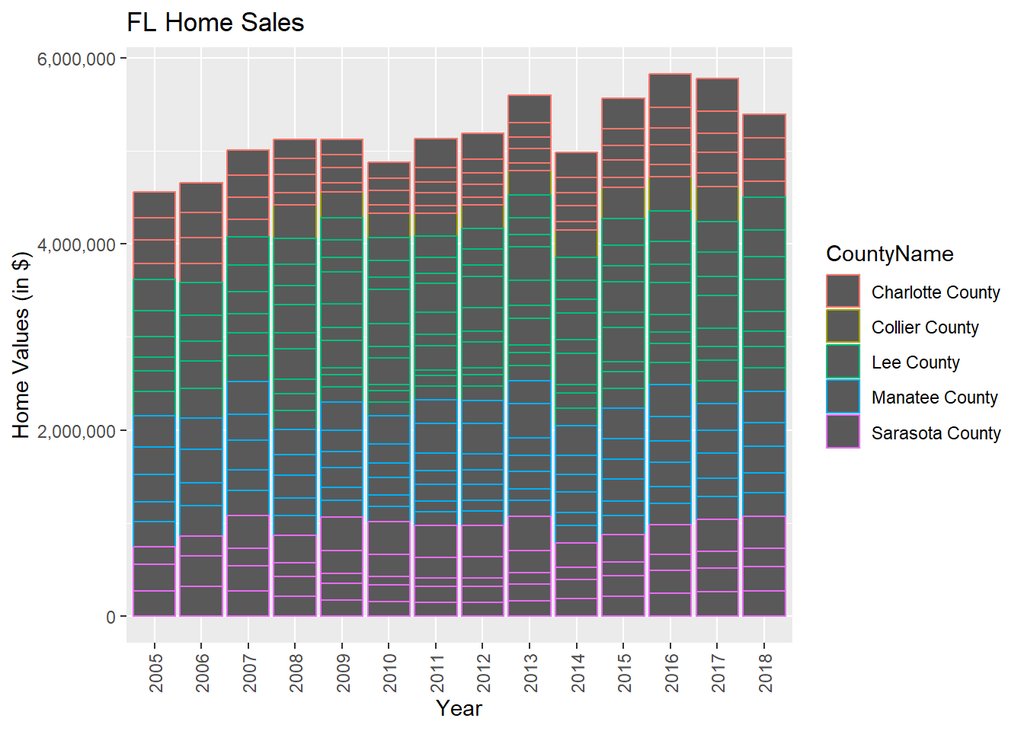

```r
#Stacked Column Chart
ggplot(flsfftmyer, aes(x=YR, y=ZHVI, color=CountyName)) +
  geom_col() +
  theme(axis.text.x = element_text(angle = 90, vjust=0.5)) +
  scale_y_continuous(name="Home Values (in $)", labels = scales::comma) +
  labs(title = "FL Home Sales",
       x="Year")
```

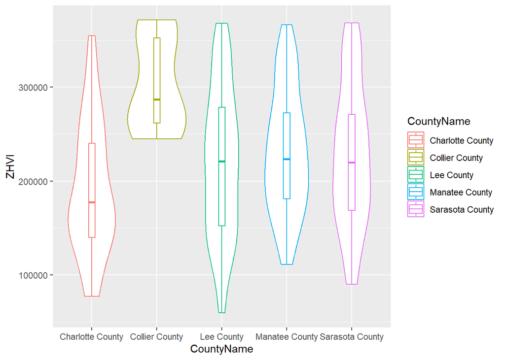

```r
#Box and Violin Plot
ggplot(flsfftmyer, aes(x=CountyName, y=ZHVI, color = CountyName)) +
  geom_violin() +
  geom_boxplot(width=0.1)
```

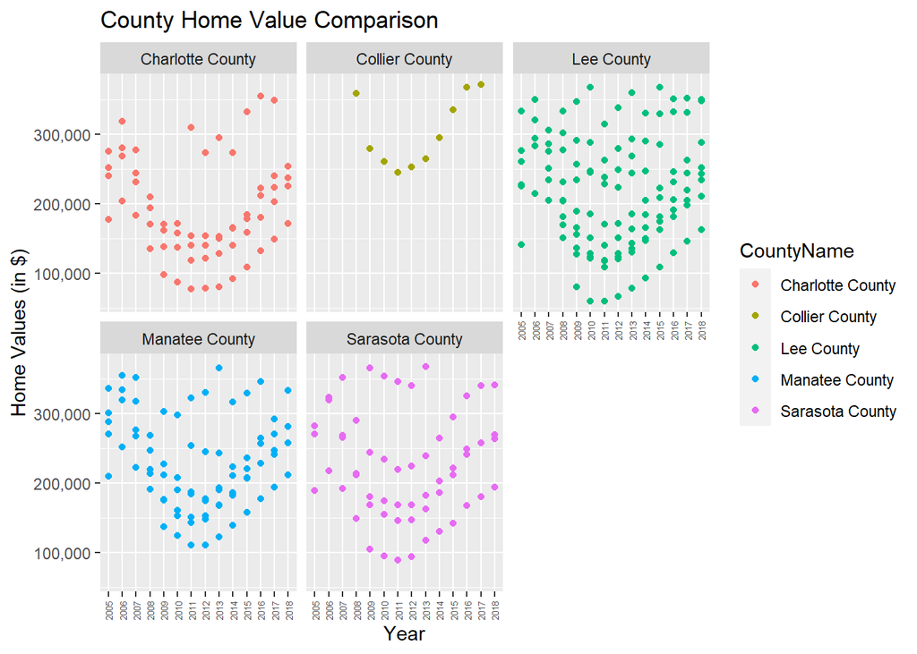

```r
#Scatter Multiple Plot
ggplot(flsfftmyer, aes(x=YR, y=ZHVI, color = CountyName)) +
  geom_point() +
  facet_wrap(~CountyName) +
  theme(axis.text.x = element_text(angle = 90, vjust=0.5, size=5)) +
  scale_y_continuous(name="Home Values (in $)", labels = scales::comma) +
  labs(title = "County Home Value Comparison",
       x="Year")
```

Now, this analysis is looking strictly at County level Home Values in order to discern where good options might be to relocate. However, this does not always mean that they would be the best option, as other factors would come in to play: employment, safety, schools, etc.

Solely based on this analysis of Home Values, and considering expected annual income, both NC and SC have reasonable options across their coastal regions. While FL has solid options in the Ocala and Date City regions, it is definitely going to require a much more granular analysis depending living conditions mentioned above. There appear to be select areas in the Jacksonville (Jax) and Ft. Myer regions that are more affordable than others, but those are fewer and farther to find.